# Faza1_rzeczowniki

Ewa Baranowska

13 maja 2016

### Przygotowanie danych

Nasze dane dotyczyły postów ze strony fanpage’a AliorBanku na facebooku. Przed przystąpieniem do analiz przepuściliśmy teksty postów przez korektę językową, po czym wybraliśmy z nich słowa zakwalifikowane jako rzeczowniki i wzięliśmy ich formę podstawową. Otrzymany wynik nie do końca nas satysfakcjonował dlatego usunęliśmy z otrzymanych rzeczowników tzw. stopwordsy, a rzeczowniki odczasownikowe, których formą podstawową jest czasownik i jako czasownik były zwracane przez aplikację, zamieniliśmy z powrotem na rzeczowniki. Wyłuskane w ten sposób rzeczowniki zapisawaliśmy w formie wyraz1|wyraz2|… do nowej kolumny. W wyniku tych działań otrzymaliśmy zbiór danych danych postaci:

|  | id | parent_id | created_at | thread_id | subject | user_name | user_link | source | body | rzeczowniki |
| --- | --- | --- | --- | --- | --- | --- | --- | --- | --- | --- |
| 2 | 1158 | 1156 | 2013-10-10 09:41:42 | 166 | NA | Lidia Wilczewska | https://www.facebook.com/lidia.wilczewska.7 | https://www.facebook.com/AliorBankSA | równania różniczkowe :) | równanie |
| 3 | 1159 | 1156 | 2013-10-10 09:43:17 | 166 | NA | Tomasz Ziółkowski | https://www.facebook.com/geografap | https://www.facebook.com/AliorBankSA | kreatywna księgowość? | księgowość |

## PUNKT WIDZENIA - RZECZOWNIKI

### Statystyki dla rzeczowników

Spójrzmy na podstawowe statystyki dotyczące rzeczowników w badanych tekstach. W naszych danych udało nam się wyodrębnić łącznie **114 497** rzeczowników, w tym **10 825** różnych (co stanowi **9.5%** całej liczby). Patrząc na rozkład ilości wystąpień rzeczowników, widzimy bardzo mocną prawostronną skośność (górny kwantyl poniżej 5, przy maksimum równym **2609**). Wynika ona z faktu, że w zbiorze znajduje się bardzo dużo rzeczowników, które pojawiły się tylko jednokrotnie.

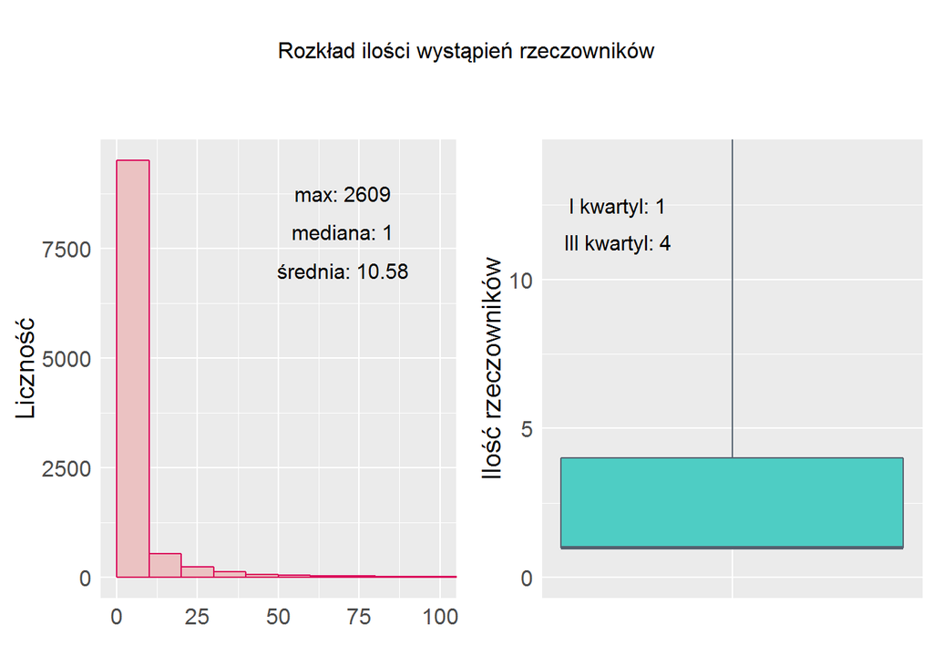

Spójrzmy na tabelę rozkładu ilości wystąpień. Widać z niej, że ponad połowa rzeczowników wystąpiła zaledwie raz.

| 1 raz | 2-5 | 6-10 | 11-50 | 51-100 | 101-1000 | 1001-2609 |
| --- | --- | --- | --- | --- | --- | --- |
| 5591 | 3181 | 736 | 969 | 168 | 171 | 9 |
| 51.65% | 29.39% | 6.8% | 8.95% | 1.55% | 1.58% | 0.08% |

Jako, że najprawdopodobniej większość z tych pojedynczych rzeczowników nie będzie miała większego znaczenia w analizach (literówki, przypadkowe użycie etc.), przedstawmy rozkład ilości wystąpień rzeczowników, ale bez tych pojedynczych wystąpień. Widać teraz, że górny kwantyl wzrósł o ponad połowę i wynosi teraz 11,a mediana 4. Zatem jeśli dane słowo się powtarzało przynajmniej raz, to połowa takich słów miała liczbę wystąpień większą lub równą 4.

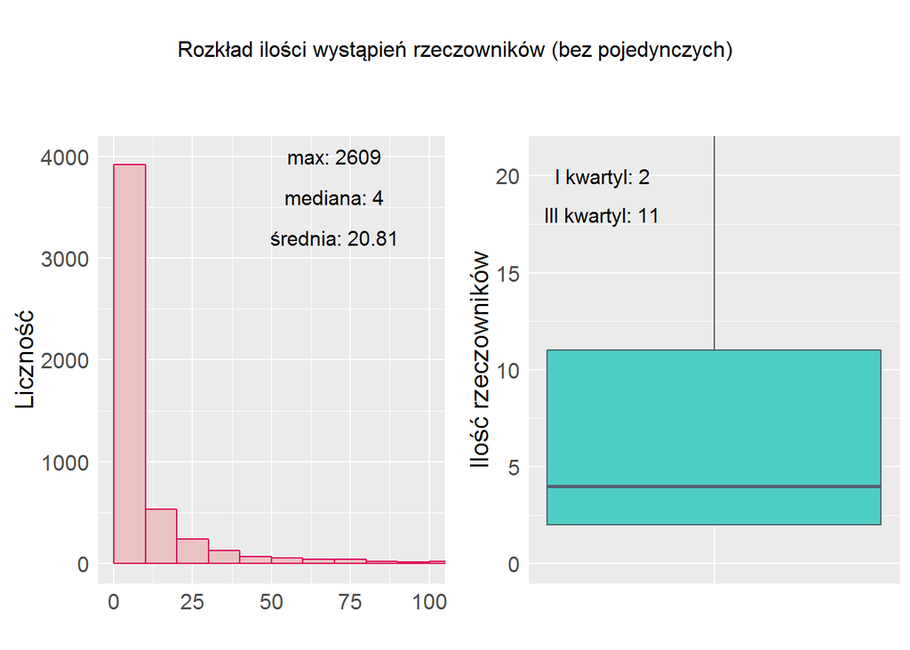

### Najpopularniejsze słowa

Zobaczmy graficznie jak przedstawiają się najpopularniejsze słowa. Widać, że większość słów jest związana z branżą bankową, tj. klient, konto, rachunek czy przelew. . Warto zwrócić uwagę, że wśród tych najczęstszych słów znajdują się dwa imiona - Magda i Kuba. Wynika to z faktu, że na posty użytkowników w imieniu banku odpowiadały osoby o tych imionach, które zawsze pod koniec posta umieszczały swoje imię.

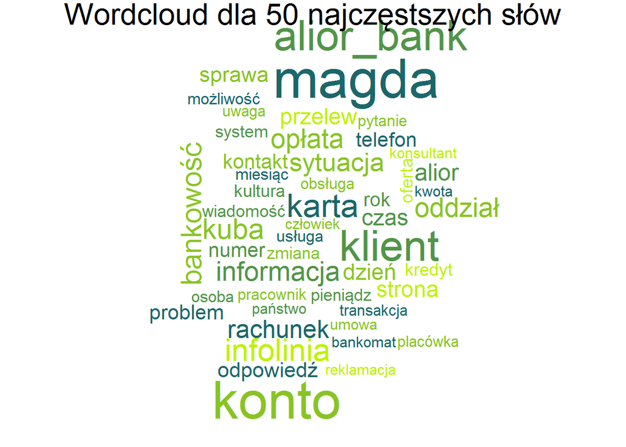

Przedstawmy ranking 10 najpopularniejszych słów wraz z ich statystykami. Jak widać najczęstszym słowem jest oczywiście **bank** z liczbą wystąpień równą **2609**. To słowo występowało w **17%** postów. Kolejnym słowem jest wspomniana Magda (**15%** postów), konto, klient, itd.

| word | rank | rank per post | count | procent | procent per post |
| --- | --- | --- | --- | --- | --- |
| bank | 1 | 1 | 2609 | 2.28 | 16.73 |
| magda | 2 | 2 | 2356 | 2.06 | 15.11 |
| konto | 3 | 3 | 2248 | 1.96 | 14.42 |
| klient | 4 | 4 | 1778 | 1.55 | 11.40 |
| alior_bank | 5 | 5 | 1715 | 1.50 | 11.00 |
| karta | 6 | 6 | 1248 | 1.09 | 8.00 |
| infolinia | 7 | 7 | 1182 | 1.03 | 7.58 |
| kuba | 8 | 8 | 1049 | 0.92 | 6.73 |
| bankowość | 9 | 9 | 1042 | 0.91 | 6.68 |
| informacja | 10 | 10 | 988 | 0.86 | 6.34 |

W tabeli umieściliśmy 2 liczby procentowe i 2 rankingi. Pierwszy ranking i procenty odnoszą się do łącznej liczby wystąpień, natomiast drugie do łącznej liczby dokumentów. Jak widać te rankingi pokrywają się dla tych 10 najpopularniejszych słów. W większości przypadków rankingi te pokrywają się lub różnią o zaledwie parę pozycji. Słowa, dla których te rankingi różnią się o więcej niz 5 wylistowaliśmy poniżej. Jest ich 14 i są to tylko rzeczowniki odczasownikowe. Występowały one częściej per post niż w łącznej sumie rzeczowników. Zwróćmy uwagę, że dla każdego z tych słów ranga w rankingu wg występowania jest wyższa (jest wyżej w rankingu) niż ranga z rankingu per post. Zatem jeśli te słowo wystąpiło to raczej w jednym poście kilkukrotnie niż pojedynczo w wielu postach.

| word | rank | rank per post | count | procent | procent per post | rozn |
| --- | --- | --- | --- | --- | --- | --- |
| zameldowanie | 3609 | 5175 | 3 | 0.00 | 0.01 | 1566 |
| wydawanie | 2037 | 2340 | 6 | 0.01 | 0.03 | 303 |
| anulowanie | 972 | 1095 | 15 | 0.01 | 0.08 | 123 |
| zamieszkanie | 1413 | 1532 | 10 | 0.01 | 0.06 | 119 |
| powstanie | 1391 | 1485 | 10 | 0.01 | 0.06 | 94 |
| doładowanie | 566 | 631 | 29 | 0.03 | 0.17 | 65 |
| wygranie | 813 | 873 | 20 | 0.02 | 0.12 | 60 |
| postępowanie | 431 | 470 | 39 | 0.03 | 0.23 | 39 |
| przetwarzanie | 694 | 715 | 24 | 0.02 | 0.15 | 21 |
| przewalutowanie | 365 | 381 | 49 | 0.04 | 0.30 | 16 |
| księgowanie | 468 | 480 | 36 | 0.03 | 0.22 | 12 |
| posiadanie | 472 | 482 | 36 | 0.03 | 0.22 | 10 |
| logowanie | 113 | 121 | 154 | 0.13 | 0.92 | 8 |
| spotkanie | 407 | 414 | 42 | 0.04 | 0.26 | 7 |

Zobaczmy przykładowy post dla słowa “anulowanie”:

**————————————————————–**

“Skontaktowałam się z Waszą infolinią, i co? I nic. Nadal wniosek wisi w powietrzu, nie ma go komu anulować, mija już 5 dzień a ja chciałam założyć w Waszym banku konto firmowe, chyba popełniłabym największy błąd w życiu bo jak miałaby działać tak samo obsługa mojego konta jak **anulowanie** wniosku, to ja bardzo podziękuje. Dzięki temu, że wniosek nadal jest aktywny wstrzymaliście mi możliwość zaciągnięcie np. pożyczki w innym banku. Jest to nie dopuszczalne, od 5 dni czekam na **anulowanie** wniosku, Wasz "bank" jest po prostu zły! Jak można tyle czekać na **anulowanie**? **Anulowanie** własnego wniosku, Wam jak raty nie zapłacę w terminie to mało głowy człowiekowi nie urwiecie! Straszycie, szantażujecie etc. Dość tego, mam prawo napisać na Was skargę. I zrobię to.”

**————————————————————-**

Czyli rzeczywiście dane potwierdzają powyższy wniosek. W przytoczonym przykładzie klient chce anulować wniosek i aby opisać swoją prośbę/problem wprost kilkukrotnie używa słowa “anulowanie”.

### Statystyki dla postów

Przyjrzyjmy się teraz rozkładowi rzeczowników w postach. W zbiorze danych mamy **15 594** posty, a na post przypada średnio **7.34** rzeczownika. Ten rozkład jak można było się spodziewać jest również prawostronnie skośny, mamy dużo postów z małą ilością rzeczowników

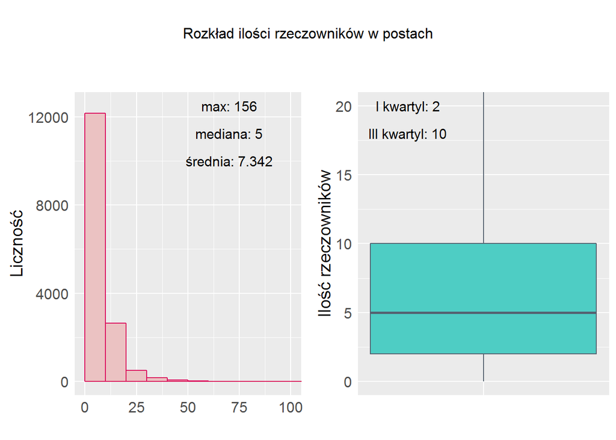

Maksymalna ilość rzeczowników w jednym poście wynosiła **156**. Post o największej ilości rzeczowników dotyczył opisu sytuacji, która miała miejsce w banku, więc duża ilość rzeczowników wynikała po pierwsze z charakteru postu jako opisu, a po drugie z jego znacznej długości.

### Rozkład wybranych słów w czasie

Spójrzmy na rozkład wybranych popularnych słów w czasie. Nasze dane pochodzą z okresu od **20 czerwca 2013** roku do **28 lutego 2016** roku, czyli mamy dane z **984** dni. W celu wykrycia nietypowych sytuacji przeanalizowaliśmy wykresy ilości wystąpień charakterystycznych słów w czasie liczonym w tygodniach. Jako nietypową liczbę wystąpień danego słowa potraktowaliśmy liczbę większą od 3 odchyleń standardowych dla wystąpień danego słowa. Z tych nietypowych liczb wybieraliśmy tą maksymalną i dla niej przeglądaliśmy posty z danego tygodnia w celu sprawdzenia powodu tak nagłego wzrostu wystapień wybranego słowa.

Zanalizowaliśmy wykres dla słowa “problem” i “awaria”. Z wykresu dla “problemu” widać wyraźmy pik w okolicach początku 2014.

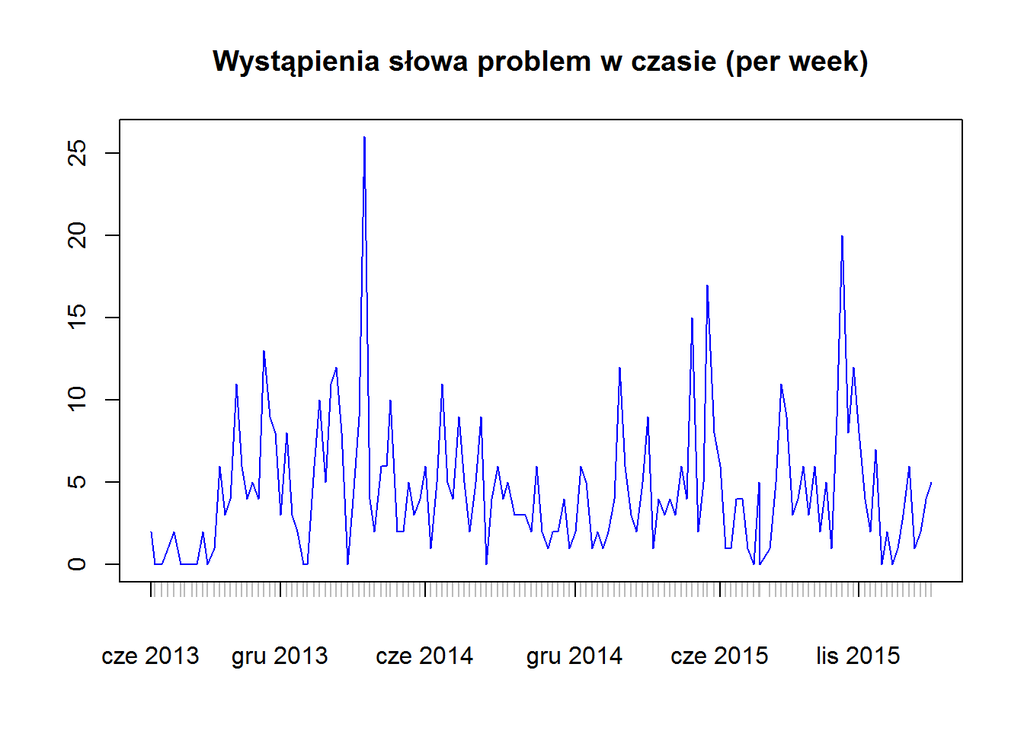

Przyjrzyjmy się typowemu postowi z tygodnia, który odpowiadał temu pikowi. Jak widać problem doryczył logowania się online na stronie internetowej banku.

| created_at | body |
| --- | --- |
| 2014-03-12 07:39:17 | czy ktoś ma dzisiaj taki sam problem ?? jak długo może to potrwać ?? Nie można połączyć się z prawdziwą witryną aliorbank.pl Coś zakłóca bezpieczne połączenie z aliorbank.pl. Spróbuj ponownie załadowa… |

Podobnie zrobiliśmy dla słowa “awaria”. Wyraźny skok był widoczny koło czerwca 2015. Z typowego postu dla tego tygodnia wynika, że awaria dotyczyła bankomatów.

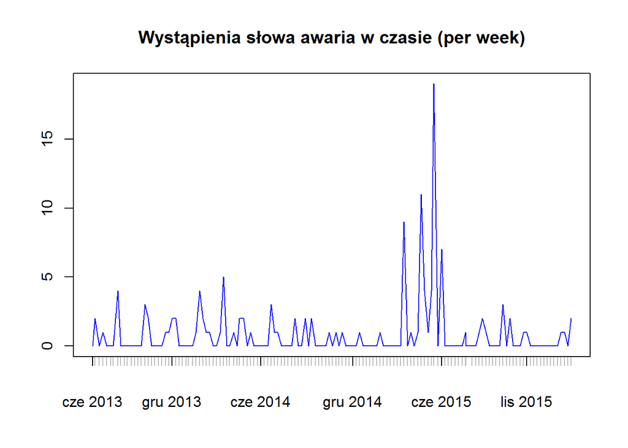

| created_at | body |
| --- | --- |
| 2015-05-21 16:18:02 | Czy jest jakas awaria? Nie moge wyplacic w bankomacie zadnej sieci, blad 413 - warszawa wlochy |